# PROYECTO 2

### Data Analytics I

#### Pelayo Ocaña Camacho

```python
# Primer paso, importamos las librerías necesarias para e desarrollo de los diferentes modelos y la importación del librería a estudiar. Dichas librerías podrán ser importadas en cada uno de los pasos futuros, como parte de dicho proceso.
```

```python
import numpy as np
import pandas as pd
import seaborn as sns
import matplotlib.pyplot as plt
```

```python
df = pd.read_csv("drug.csv", decimal=",", delimiter = ",")
```

1. **`Age`**
   - Tipo: Cuantitativa
   - Descripción: Indica la **edad del paciente**.
2. **`BP` (Blood Pressure)**
   - Tipo: Categórica
   - Descripción: Representa la **presión arterial del paciente**.
3. **`Cholesterol`**
   - Tipo: Categórica
   - Descripción: Indica el **nivel de colesterol en sangre del paciente**.
4. **`Na`** (Sodio)
   - Tipo: Cuantitativa (transformada)
   - Descripción: Indica el **nivel de sodio** en la sangre del paciente.
5. **`K`** (Potasio)
   - Tipo: Cuantitativa (transformada)
   - Descripción: Indica el **nivel de potasio** en la sangre del paciente.
6. **`Drug`**
   - Tipo: Categórica
   - Descripción: Indica la **droga a suministrar** al paciente.

# Imprimimos para ver la base de datos

```python
print(df)
```

```
     Age Sex      BP Cholesterol        Na         K   Drug
0     23   F    HIGH        HIGH  0.792535  0.031258  drugY
1     47   M     LOW        HIGH  0.739309  0.056468  drugC
2     47   M     LOW        HIGH  0.697269  0.068944  drugC
3     28   F  NORMAL        HIGH  0.563682  0.072289  drugX
4     61   F     LOW        HIGH  0.559294  0.030998  drugY
..   ...  ..     ...         ...       ...       ...    ...
195   56   F     LOW        HIGH  0.848774   0.07338  drugC
196   16   M     LOW        HIGH  0.743021  0.061886  drugC
197   52   M  NORMAL        HIGH  0.549945  0.055581  drugX
198   23   M  NORMAL      NORMAL   0.78452  0.055959  drugX
199   40   F     LOW      NORMAL  0.683503  0.060226  drugX

[200 rows x 7 columns]
```

**Resumen Estadístico para Datos Cuantitativos**

```python
# Primer utilizamos la función describe para tener datso estadísticos de nuestra dataset, sin embargo sólo nos prporciona información detallada acerca de la única variable cuantitativa de naturaleza "int". Sin, embargo llevamos a cabo la conversión de variables como K y Na, potasio y sodio, consideradas interesantes para el estudio.
```

```python
df.info()
```

```
<class 'pandas.core.frame.DataFrame'>
RangeIndex: 200 entries, 0 to 199
Data columns (total 7 columns):
 #   Column       Non-Null Count  Dtype
---  ------       --------------  -----
 0   Age          200 non-null    int64
 1   Sex          200 non-null    object
 2   BP           200 non-null    object
 3   Cholesterol  200 non-null    object
 4   Na           200 non-null    object
 5   K            200 non-null    object
 6   Drug         200 non-null    object
dtypes: int64(1), object(6)
memory usage: 11.1+ KB
```

```python
resumen = df.describe(include='all')
print(resumen)
```

```
               Age  Sex    BP Cholesterol        Na         K   Drug
count   200.000000  200   200         200       200       200    200
unique         NaN    2     3           2       200       200      5
top            NaN    M  HIGH        HIGH  0.792535  0.031258  drugY
freq           NaN  104    77         103         1         1     91
mean     44.315000  NaN   NaN         NaN       NaN       NaN    NaN
std      16.544315  NaN   NaN         NaN       NaN       NaN    NaN
min      15.000000  NaN   NaN         NaN       NaN       NaN    NaN
25%      31.000000  NaN   NaN         NaN       NaN       NaN    NaN
50%      45.000000  NaN   NaN         NaN       NaN       NaN    NaN
75%      58.000000  NaN   NaN         NaN       NaN       NaN    NaN
max      74.000000  NaN   NaN         NaN       NaN       NaN    NaN
```

```python
for col in ['Na', 'K']:
    try:
        df[col] = pd.to_numeric(df[col])  # Convertir a numérico si es posible
        print(f"{col} se convirtió a numérico.")
    except ValueError:
        print(f"{col} no se pudo convertir a numérico.")
```

```
Na se convirtió a numérico.
K se convirtió a numérico.
```

```python
df.describe()
# Empleamos la función describe(), con el objetivo de conocer información de carácter estadístico para las variables cuantitativas. Como son las siguientes.
# explicar información en el informe
```

|  | Age | Na | K |
| --- | --- | --- | --- |
| count | 200.000000 | 200.000000 | 200.000000 |
| mean | 44.315000 | 0.697095 | 0.050174 |
| std | 16.544315 | 0.118907 | 0.017611 |
| min | 15.000000 | 0.500169 | 0.020022 |
| 25% | 31.000000 | 0.583887 | 0.035054 |
| 50% | 45.000000 | 0.721853 | 0.049663 |
| 75% | 58.000000 | 0.801494 | 0.066000 |
| max | 74.000000 | 0.896056 | 0.079788 |

**Resumen Estadístico para Datos Categóricos**

```python
# Una vez hemos identificado los dos grupos de variables, atendiendo a su naturaleza. Hemos agrupado las variables categóricas, en esta variable.
# Esta agrupación se ha hecho con el objetivo de facilitar el estudio estadístico inicla, para estas variables.
# Utilizamos la función value_counts(), que nos permite identificar un conteo, en base a características comunes de posibles pacientes.
# En la gráfica de abajo, hemos refinado este código anteior, añadiensole la función size, que nos permite tener de manera mas esquamtizada la aplicación de droga, en función al resto de variables.
```

```python
datos_categoricos = df[["Sex", "BP", "Cholesterol", "Drug"]]
```

```python
datos_categoricos.value_counts()
```

```
Sex  BP      Cholesterol  Drug
F    HIGH    NORMAL       drugY    14
     NORMAL  HIGH         drugX    12
M    NORMAL  HIGH         drugY    11
     LOW     NORMAL       drugX    10
     HIGH    NORMAL       drugY     9
F    HIGH    HIGH         drugY     9
M    NORMAL  NORMAL       drugX     9
     LOW     HIGH         drugC     9
             NORMAL       drugY     9
             HIGH         drugY     8
F    LOW     NORMAL       drugX     8
M    NORMAL  HIGH         drugX     8
     HIGH    NORMAL       drugA     8
F    NORMAL  NORMAL       drugX     7
     LOW     HIGH         drugY     7
                          drugC     7
     HIGH    HIGH         drugA     6
M    HIGH    HIGH         drugA     6
                          drugY     6
                          drugB     6
F    NORMAL  HIGH         drugY     6
     LOW     NORMAL       drugY     6
     NORMAL  NORMAL       drugY     5
M    HIGH    NORMAL       drugB     4
F    HIGH    NORMAL       drugB     4
                          drugA     3
             HIGH         drugB     2
M    NORMAL  NORMAL       drugY     1
Name: count, dtype: int64
```

```python
datos_categoricos.nunique()
# Empleamos esta función con el objetivo de conocer cuantas posibilidades hay dentro de cada variables categórica, es decir, cuantas sub categorías podemos encontrar.
```

```
Sex            2
BP             3
Cholesterol    2
Drug           5
dtype: int64
```

```python
resultado = df.groupby(['Sex', 'BP', 'Cholesterol', 'Drug']).size()
print(resultado)
```

```
Sex  BP      Cholesterol  Drug
F    HIGH    HIGH         drugA     6
                          drugB     2
                          drugY     9
             NORMAL       drugA     3
                          drugB     4
                          drugY    14
     LOW     HIGH         drugC     7
                          drugY     7
             NORMAL       drugX     8
                          drugY     6
     NORMAL  HIGH         drugX    12
                          drugY     6
             NORMAL       drugX     7
                          drugY     5
M    HIGH    HIGH         drugA     6
                          drugB     6
                          drugY     6
             NORMAL       drugA     8
                          drugB     4
                          drugY     9
     LOW     HIGH         drugC     9
                          drugY     8
             NORMAL       drugX    10
                          drugY     9
     NORMAL  HIGH         drugX     8
                          drugY    11
             NORMAL       drugX     9
                          drugY     1
dtype: int64
```

## **IDENTIFICACIÓN DE VALORES FALTANTES Y POSIBLES INCONSISTENCIAS**

```python
df.isnull()
# Tras ejecutar este código, apreciamos que no hay valores faltantes en nuestro dataset. En caso de haberlos, se nos mostraría True en vez de false.
```

|  | Age | Sex | BP | Cholesterol | Na | K | Drug |
| --- | --- | --- | --- | --- | --- | --- | --- |
| 0 | False | False | False | False | False | False | False |
| 1 | False | False | False | False | False | False | False |
| 2 | False | False | False | False | False | False | False |
| 3 | False | False | False | False | False | False | False |
| 4 | False | False | False | False | False | False | False |
| ... | ... | ... | ... | ... | ... | ... | ... |
| 195 | False | False | False | False | False | False | False |
| 196 | False | False | False | False | False | False | False |
| 197 | False | False | False | False | False | False | False |
| 198 | False | False | False | False | False | False | False |
| 199 | False | False | False | False | False | False | False |

200 rows × 7 columns

```python
faltantes_por_columna = df.isnull().sum()

print(faltantes_por_columna)
```

```
Age            0
Sex            0
BP             0
Cholesterol    0
Na             0
K              0
Drug           0
dtype: int64
```

#### Preguntar por tutoría, información obetnida de internet

```python
inconsistencias_Na = df[(df['Na'] < 135) | (df['Na'] > 145)]
inconsistencias_K = df[(df['K'] < 3.5) | (df['K'] > 5.5)]

print(inconsistencias_Na)
print(inconsistencias_K)
```

```
     Age Sex      BP Cholesterol        Na         K   Drug
0     23   F    HIGH        HIGH  0.792535  0.031258  drugY
1     47   M     LOW        HIGH  0.739309  0.056468  drugC
2     47   M     LOW        HIGH  0.697269  0.068944  drugC
3     28   F  NORMAL        HIGH  0.563682  0.072289  drugX
4     61   F     LOW        HIGH  0.559294  0.030998  drugY
..   ...  ..     ...         ...       ...       ...    ...
195   56   F     LOW        HIGH  0.848774  0.073380  drugC
196   16   M     LOW        HIGH  0.743021  0.061886  drugC
197   52   M  NORMAL        HIGH  0.549945  0.055581  drugX
198   23   M  NORMAL      NORMAL  0.784520  0.055959  drugX
199   40   F     LOW      NORMAL  0.683503  0.060226  drugX

[200 rows x 7 columns]
     Age Sex      BP Cholesterol        Na         K   Drug
0     23   F    HIGH        HIGH  0.792535  0.031258  drugY
1     47   M     LOW        HIGH  0.739309  0.056468  drugC
2     47   M     LOW        HIGH  0.697269  0.068944  drugC
3     28   F  NORMAL        HIGH  0.563682  0.072289  drugX
4     61   F     LOW        HIGH  0.559294  0.030998  drugY
..   ...  ..     ...         ...       ...       ...    ...
195   56   F     LOW        HIGH  0.848774  0.073380  drugC
196   16   M     LOW        HIGH  0.743021  0.061886  drugC
197   52   M  NORMAL        HIGH  0.549945  0.055581  drugX
198   23   M  NORMAL      NORMAL  0.784520  0.055959  drugX
199   40   F     LOW      NORMAL  0.683503  0.060226  drugX

[200 rows x 7 columns]
```

## **VISUALIZACIÓN DE DISTRIBUCIONES Y RELACIONES ENTRE VARIABLES**

```python
# Representamos la distribución de la edad de las muestras obtenidas, podemos identificar una predominancia de los pacientes cuya edad se sitúa cercana a los 20 y los 50.
```

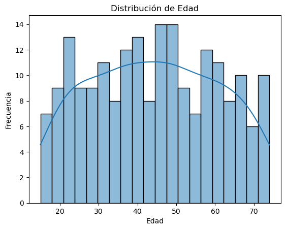

```python
import matplotlib.pyplot as plt
import seaborn as sns

# Ejemplo de histograma para la variable 'Age'
sns.histplot(df['Age'], kde=True, bins=20)
plt.title('Distribución de Edad')
plt.xlabel('Edad')
plt.ylabel('Frecuencia')
plt.show()
```

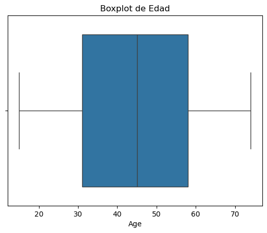

```python
# Ejemplo de boxplot para la variable 'Age'
sns.boxplot(x=df['Age'])
plt.title('Boxplot de Edad')
plt.show()

# En este diagrama de caja, podemos observar la gran acumulación de edad entre las cifras indicadas.
```

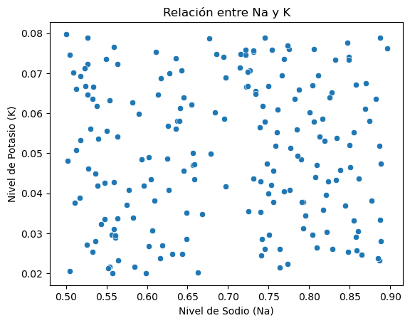

```python
# Ejemplo de gráfico de dispersión entre 'Na' y 'K'
sns.scatterplot(x=df['Na'], y=df['K'])
plt.title('Relación entre Na y K')
plt.xlabel('Nivel de Sodio (Na)')
plt.ylabel('Nivel de Potasio (K)')
plt.show()
```

**Representación de Distribución de Variables Cuantitativas**

```python
# Seleccionar solo las columnas cuantitativas
quantitative_columns = ['Age', 'Na', 'K']

# Calcular la matriz de correlación
correlation_matrix = df[quantitative_columns].corr()

# Ver la matriz de correlación
print(correlation_matrix)

# Empleamos la marriz de correlación, para tener una idea acerca de la importancia que tienen una variables sobre otras y si sus cambios se afectan simultaneamente.
# Como es el caso de estas variables, todas presentan una correlación inferior al 0,7, lo que nos indica que no están correlacionadas.
# Puede ser beneficioso, ya que en caso de haber excesiva correlación de lugar el sobreajuste o sesgo de los datos.
```

```
          Age        Na         K
Age  1.000000  0.100371  0.111491
Na   0.100371  1.000000  0.017335
K    0.111491  0.017335  1.000000
```

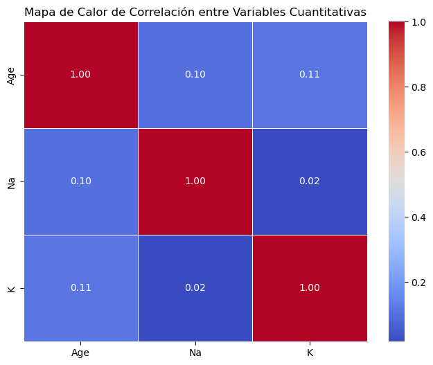

```python
import seaborn as sns
import matplotlib.pyplot as plt

# Crear el mapa de calor
plt.figure(figsize=(8, 6))  # Ajustar tamaño del gráfico
sns.heatmap(correlation_matrix, annot=True, cmap='coolwarm', fmt='.2f', linewidths=0.5)

# Título
plt.title('Mapa de Calor de Correlación entre Variables Cuantitativas')

# Mostrar gráfico
plt.show()

# Empleamos esta herramienta, el apa de calor para reflejar de manera mas visual la información presentada anteiormente, donde los colores mas cercanos al rojo indican una alta correlación, sin embargo, ninguno cumple dicha condición, por lo que concluímos con que su correlación es baja.
```

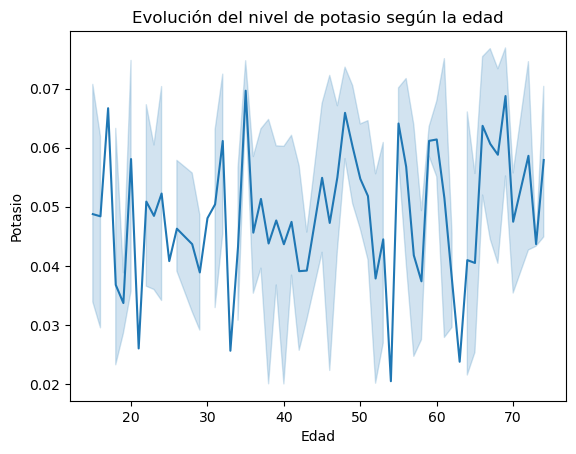

```python
# Gráfico de líneas de 'Age' (ejemplo de serie temporal)
# Este es solo un ejemplo si tu dataset tiene un índice o variable temporal.
sns.lineplot(x=df['Age'], y=df['K'])
plt.title('Evolución del nivel de potasio según la edad')
plt.xlabel('Edad')
plt.ylabel('Potasio')
plt.show()

# Medimos la evolución del nivel del potasio en sangre según la edad del paciente. Podemos destacar un pico excesivamente alto en torno a los 35 años, al contrario que los 65 años, donde dicho pico es excesivamente bajo.
```